# Leachate Analysis from 2025 Greenhouse Study

Renee Davis

2026-02-03

[GitHub repository](https://github.com/reneeadeledavis/biobead/tree/main/2025greenhouse)

# 1 Methods

## 1.1 Sample Collection and Analysis

Leachate samples were analyzed for ammonium (NH₄⁺-N), nitrate (NO₃⁻-N), and phosphate (PO₄³⁻-P) concentrations using a Gallery™ Analyzer (ThermoFisher Scientific). A water blank was included in each analytical run for quality control. Due to the sensitivity of phosphate to freezing, samples were stored at 4°C and analyzed within 24 hours of collection to prevent degradation.

## 1.2 Data Analysis

General trends in nutrient leachate data (NO₃⁻, NH₄⁺, PO₄³⁻) were visualized using violin plots.

Data were analyzed separately for each sampling week using one-way analysis of variance (ANOVA) with treatment as the fixed factor. Prior to analysis, ANOVA assumptions were verified by visual inspection of residual plots and Shapiro-Wilk tests for normality. For datasets meeting parametric assumptions, Tukey’s Honest Significant Difference (HSD) post-hoc tests were conducted to identify pairwise differences among treatments (α = 0.05).

All analyses were conducted in R version 2025.09.2+418 using the base stats package, tidyverse, dplyr. Plots were generated with the ggstatsplot, ggplot2, plotrix, and ggpubr.

## 1.3 Hypotheses

1. Treatments with nitrogen-fixing bacteria (T1, T3, T4, T5, T7, T9) will exhibit elevated ammonium leachate concentrations compared to untreated controls due to enhanced N fixation in the plant-soil system.
2. Treatments containing AMF (T2, T3, T4, T6) will show reduced phosphate leachate compared to non-AMF treatments due to direct P transfer to plants via mycorrhizal networks.
3. Combined bacteria+AMF treatments (T3, T4) will demonstrate synergistic effects, showing lower leachate concentrations of all three nutrients compared to single-inoculant treatments due to complementary nutrient acquisition strategies.
4. Strigolactone-primed treatments (T4, T5, T6) will exhibit lower nutrient leachate at later timepoints (weeks 6-8) compared to non-primed equivalents due to accelerated AMF colonization and symbiosis establishment.
5. Synthetic fertilizer (T13) will show highest nutrient leachate concentrations, particularly early in the study, due to rapid nutrient availability exceeding plant uptake capacity.

# 2 Results

## 2.1 Week 2 Analysis

### 2.1.1 Faceted violin plot

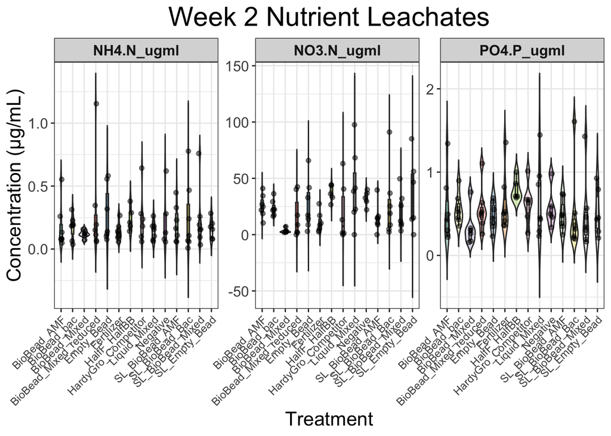

### 2.1.2 Correlation scatterplots

Correlation scatterplots were generated to assess the correlations between nitrate and phosphate and ammonium.

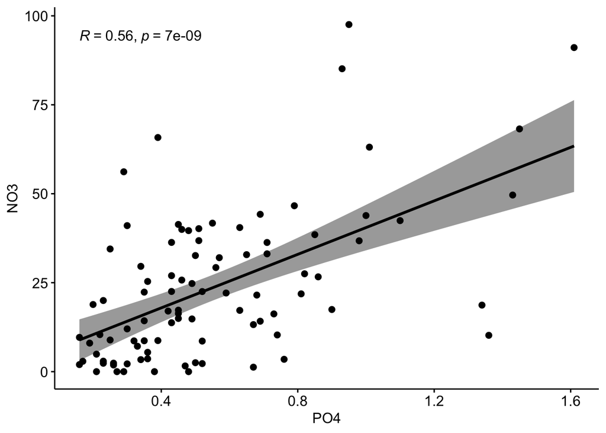

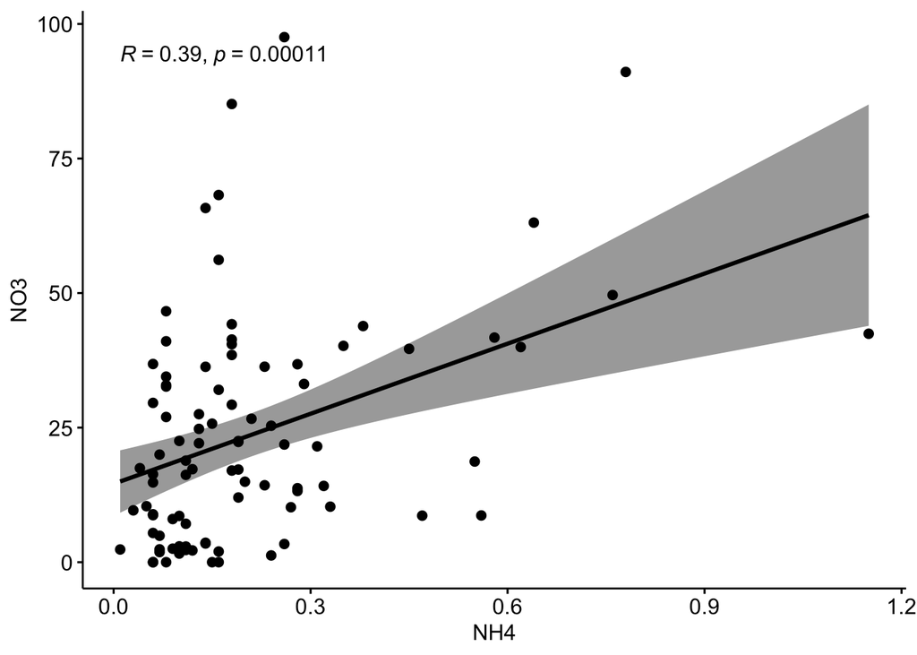

### 2.1.3 One Way ANOVA

```r
summary(anova_NH4_wk2)
```

```
##                    Df Sum Sq Mean Sq F value Pr(>F)
## Treatment_Category 13 0.2583 0.01987   0.517  0.908
## Residuals          77 2.9601 0.03844
```

```r
summary(anova_NO3_wk2)
```

```
##                    Df Sum Sq Mean Sq F value Pr(>F)
## Treatment_Category 13   9209   708.4   1.821 0.0544 .
## Residuals          77  29947   388.9
## ---
## Signif. codes:  0 '***' 0.001 '**' 0.01 '*' 0.05 '.' 0.1 ' ' 1
```

```r
summary(anova_PO4_wk2)
```

```
##                    Df Sum Sq Mean Sq F value Pr(>F)
## Treatment_Category 13  0.868 0.06675   0.653  0.801
## Residuals          77  7.866 0.10216
```

There were no significant differences among treatment groups for ammonium and phosphate concentrations in leachate. Nitrate concentrations differed marginally between treatments (0.0544).

### 2.1.4 Tukey Test

There were no significant differences among treatment groups for ammonium and phosphate concentrations in leachate. Nitrate concentrations different marginally between Liquid_Mixed vs BioBead_Mixed (p = 0.0523), with Liquid_Mixed associated with higher concenrations.

### 2.1.5 Shapiro Wilk test for normality

```
##
##  Shapiro-Wilk normality test
##
## data:  anova_NH4_wk2$residuals
## W = 0.83315, p-value = 9.807e-09
```

```
##
##  Shapiro-Wilk normality test
##
## data:  anova_NO3_wk2$residuals
## W = 0.92787, p-value = 8.344e-05
```

```
##
##  Shapiro-Wilk normality test
##
## data:  anova_PO4_wk2$residuals
## W = 0.86564, p-value = 1.393e-07
```

Together, the W values for all ANOVA tests (0.83-0.93) indicate deviation from normality. The very low p values indicate that there are significant differences in normality. Therefore, alternative statistical analyses should be considered.

### 2.1.6 Residuals distribution

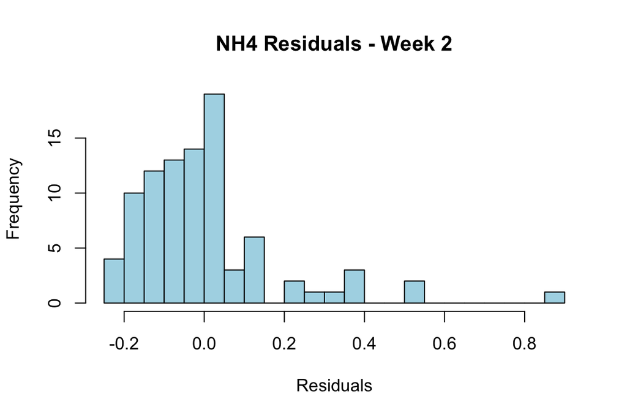

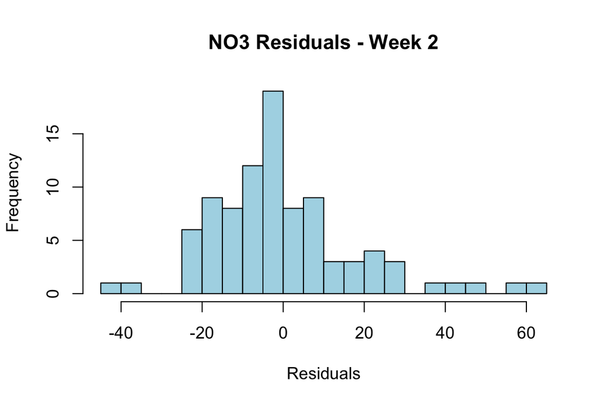

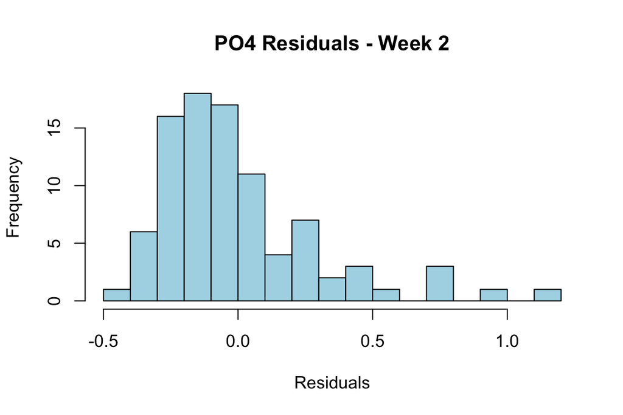